# Setup

A scientist and statistician are collaborating on understanding the visual system. The scientist presents a series of \(K\) stimuli (pictures) to the subject and records the subject's response to each stimuli as a \(p\)-dimensional vector. Let \(y_i\) denote the subject's responses to the \(i\) th picture.

The statistican seeks to model the subject's response to the stimuli in terms of a set of \(q\) stimulus features. For example, the statistician might define a library of \(q = 10000\) Gabor filters to featurize each picture. Let \(x_i\) denote the \(q\)-dimensional feature vector for each picture.

Let us assume the following multivariate regression model for the data. We have \[ y_i = x_i^T B + \epsilon_i \] so the subject's response is a linear function of the image features plus noise. Here \(B\) is a \(q \times p\) matrix. Let us write \(\vec{B}\) as the \(qp \times 1\) vectorized representation of \(B\), and further suppose that \(\vec{B}\) is a random variate \[ \vec{B} \sim N(0, \Sigma_B) \] and that the \(\epsilon_i\) are indenpendent of the \(B\), with \(\epsilon_i\) i.i.d. \[ \epsilon_i \sim N(0,\Sigma_\epsilon) \]

```r
set.seed(0)
library(pracma)
library(magrittr)
library(MASS)
K <- 30 # number of stimuli
p <- 20 # dimension of response
q <- 8 # dimension of features
# true noise covariance
Sigma_E <- 2/p * randn(2 * p, p) %>% { t(.) %*% . }
# true signal covariance = sB * I
sB0 <- 2
B0 <- sqrt(sB0) * randn(q, p)
# random features
X <- randn(K, q)
# noise
E <- mvrnorm(K, rep(0, p), Sigma_E)
# observations
Y <- X %*% B0 + E
```

Now supposing the statistican knows the exact value of \(\Sigma_\beta\) and \(\Sigma_\epsilon\), it is a standard result in Bayesian inference that the posterior distribution for \(\vec{B}\) can be obtained as \[ \vec{B} \sim N( (Z^T \Sigma_E^{-1} Z + \Sigma_B^{-1})^{-1} Z^T \Sigma_E^{-1} \vec{Y}, (Z^T \Sigma_E^{-1} Z +\Sigma_B^{-1})^{-1}) \]

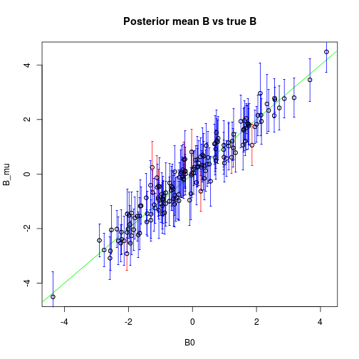

```r
# posterior mean
B_mu <- solve(t(X) %*% X + 1/sB0 * diag(rep(1, q))) %*% t(X) %*% Y
# posterior variance per column
post_cov_B_col <- solve(t(X) %*% X + 1/sB0 * diag(rep(1, q)) )
# marginal variances of B
post_var_B <- t(t(diag(post_cov_B_col))) %*% diag(Sigma_E)
# upper and lower intervals
B_up <- B_mu + 2 * sqrt(post_var_B)
B_low <- B_mu - 2 * sqrt(post_var_B)
# plot
plot(B0, B_mu, main = "Posterior mean B vs true B"); abline(0, 1, col = "green")
for (i in 1:q) { for (j in 1:p) {
  if (B_low[i,j] < B0[i, j] && B_up[i, j] > B0[i, j]) {
    cc <- "blue"
  } else {
    cc <- "red"
  }
  lines(rep(B0[i, j], 2), c(B_low[i, j], B_up[i, j]), col = cc)
  points(rep(B0[i, j], 2), c(B_low[i, j], B_up[i, j]), pch = "-", col = cc)
}}
points(B0, B_mu)
```

The posterior distribution of \(\mu_i\) are given as follows:

\[ \text{E}(\mu_i) = (x_i)^T \text{E}(B) \]

\[ \text{Cov}(\mu_i, \mu_j) = (I_p \otimes (x_i)^T) \text{Cov}(B) (I_p \otimes x_j) \]

```r
post_cov_B_vec <- solve(solve(Sigma_E) %x% (t(X) %*% X) + 1/sB0 * diag(rep(1, p * q)))
f_post_cov_mu <- function(xi, xj) {
  (diag(rep(1, p)) %x% t(xi)) %*% post_cov_B_vec %*% (diag(rep(1, p)) %x% t(t(xj)))
}
```

# Identification

Now the scientist wishes to test the statistician's model. The scientist obtains *new* stimuli \(x^{te}_1, …, x^{te}_L\). They randomly present one of the stimuli \(i^* \sim Unif\{1,…, L \}\) and record the response of the subject, \(y^*\). The scientist challenges the statistician to identify which stimuli \(x^{te}_i\) from among \(\{x^{te}_1,…, x^{te}_L\}\) was presented to the subject, based on the response \(y^*\).

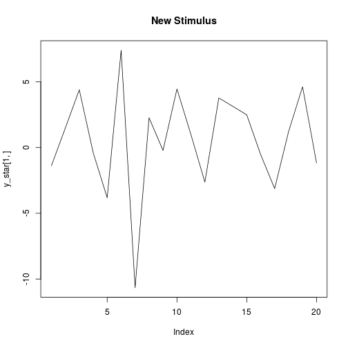

```r
# new stimuli
L <- 3
X_te <- randn(L, q)
i_chosen <- sample(L, 1)
y_star <- X_te[i_chosen, , drop = FALSE] %*% B0 +  mvrnorm(1, rep(0, p), Sigma_E)
plot(y_star[1, ], type = "l", main = "New Stimulus")
```

The statistician can compute the posterior distribution of \(\mu_i^{te}\) for each of the candidate images, and compute the posterior probability that the new response came from each stimulus. The log posterior probability is proportional to

\[ \text{Pr}(i^* = i) = -\log \det(\text{Cov}(\mu_i^{te})) - (y^* - \text{E}[\mu_i^{te}])^T (\text{Cov}(\mu_i^{te}) + \Sigma_\epsilon)^{-1} (y^* - \text{E}[\mu_i^{te}]) \]

The plot shows \(y^*\) superimposed on posterior draws from each distribution.

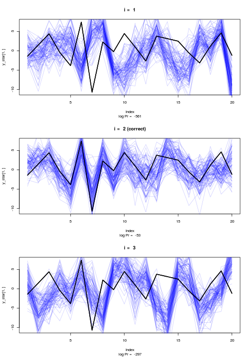

```r
layout(matrix(1:3, 3, 1))
mus <- list(L)
covs <- list(L)
cc <- rgb(0, 0, 1, alpha = 0.2)
for (i in 1:L) {
  mus[[i]] <- X_te[i, , drop = FALSE] %*% B_mu
  covs[[i]] <- f_post_cov_mu(X_te[i, ], X_te[i, ]) + Sigma_E
  pprob <- -log(det(covs[[i]])) - (y_star - mus[[i]]) %*% solve(covs[[i]]) %*% t(y_star - mus[[i]])
  plot(y_star[1, ], type = "l", lwd = 2)
  for (j in 1:100) lines(mvrnorm(1, mu = mus[[i]], Sigma = covs[[i]] + Sigma_E), col = cc)
  if (i == i_chosen) {
    title(paste("i = ", i, "(correct)"), sub = paste("log Pr = ", floor(pprob)))
  } else {
    title(paste("i = ", i), sub = paste("log Pr = ", floor(pprob)))
  }
  lines(y_star[1, ], type = "l", lwd = 2)
}
```

```r
layout(1)
```

# Empirical Bayes

The previous approach relies on knowing \(\Sigma_\epsilon\), \(\Sigma_B\). However, in practice, we seldom have a prior estimate of these quantities. We can estimate \(\hat{\Sigma}_\epsilon\) from the covariance of the residuals. But what about \(\Sigma_B\)? Taking advantage of the connection between ridge regression and the normal prior \(\beta \sim N(0, \lambda^{-1} I)\), we propose to estimate \(\Sigma_B\) using the optimal ridge regression shrinkage values.

```r
library(glmnet)
B_mu_EB <- matrix(0, q, p) # placeholder for estimate
resids <- matrix(0, K, p)
lambdas <- numeric(p) # lambda for each column of B
for (i in 1:p) {
  res <- cv.glmnet(X, Y[, i], alpha = 0, intercept = FALSE, standardize = FALSE)
  lambdas[i] <- res$lambda.1se
  pre <- predict(res, s = lambdas[i], newx = X)
  resids[, i] <- pre - Y[, i]
  B_mu_EB[, i] <- as.numeric(coefficients(res))[-1]
}
```

Compare \(\hat{B}_{EB}\) from empirical bayes, \(\hat{B}_{bayes}\) and true \(B\).

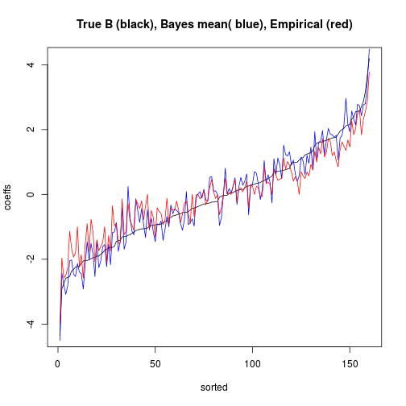

```r
o <- order(as.numeric(B0))
plot(as.numeric(B0)[o], type = "l", xlab = "sorted", ylab = "coeffs")
lines(as.numeric(B_mu)[o], col = "blue")
lines(as.numeric(B_mu_EB)[o], col = "red")
title("True B (black), Bayes mean( blue), Empirical (red)")
```

Form empirical bayes estimates of \(\Sigma_E\) and \(\Sigma_B\)

```r
Sigma_E_hat <- cov(resids)
Inv_Sigma_B <- diag(rep(lambdas, each = q))
EB_cov_B_vec <- solve(solve(Sigma_E_hat) %x% (t(X) %*% X) + Inv_Sigma_B)
f_EB_cov_mu <- function(xi, xj) {
  (diag(rep(1, p)) %x% t(xi)) %*% EB_cov_B_vec %*% (diag(rep(1, p)) %x% t(t(xj)))
}
```

Identify \(y^*\) using Empirical Bayes.

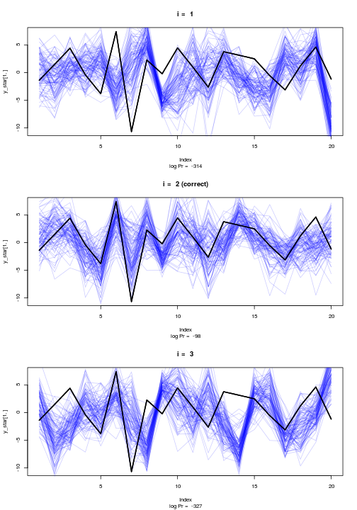

```r
layout(matrix(1:3, 3, 1))
mus <- list(L)
covs <- list(L)
cc <- rgb(0, 0, 1, alpha = 0.2)
for (i in 1:L) {
  mus[[i]] <- X_te[i, , drop = FALSE] %*% B_mu_EB
  covs[[i]] <- f_EB_cov_mu(X_te[i, ], X_te[i, ]) + Sigma_E_hat
  pprob <- -log(det(covs[[i]])) - (y_star - mus[[i]]) %*% solve(covs[[i]]) %*% t(y_star - mus[[i]])
  plot(y_star[1, ], type = "l", lwd = 2)
  for (j in 1:100) lines(mvrnorm(1, mu = mus[[i]], Sigma = covs[[i]] + Sigma_E_hat), col = cc)
  if (i == i_chosen) {
    title(paste("i = ", i, "(correct)"), sub = paste("log Pr = ", floor(pprob)))
  } else {
    title(paste("i = ", i), sub = paste("log Pr = ", floor(pprob)))
  }
  lines(y_star[1, ], type = "l", lwd = 2)
}
```

```r
layout(1)
```